# ROI data in R

First we load some packages and set the paths:

```r
library(ZooDVM)

check.packages <- function(pkg){
  new.pkg <- pkg[!(pkg %in% installed.packages()[, "Package"])]
  if (length(new.pkg))
    install.packages(new.pkg, dependencies = TRUE, INSTALL_opts = '--no-lock')
  sapply(pkg, require, character.only = TRUE)
}
check.packages(c('mgcViz','mgcv','rpart','rpart.plot'))
```

```
##     mgcViz       mgcv      rpart rpart.plot
##       TRUE       TRUE       TRUE       TRUE
```

```r
library(mgcViz)
library(mgcv)
library(rpart)
library(rpart.plot)

datadir <-'C:\\Users\\sven\\Documents\\Zonar\\data\\csv_zonar\\'
roidir <- 'C:\\Users\\sven\\Documents\\Zonar\\data\\csv_zc_roi\\'
```

Then we load Sv, gps and environamnet data.

```r
#get missions
mm = get_mission(datadir)
sel = grep('*PtSur*',mm$missions)
mission = mm$missions[sel]

#get Sv data
Sv = get_sv(datadir,sel)

#get GPS info
gps = get_gps( ZooDVM::ncpath_from_csvpath(datadir), sel)

#gen environmental data
env = get_env( ZooDVM::ncpath_from_csvpath(datadir), sel)
```

# Getting Zoocam ROIs size class info

If the standard folder structure is maintained, the pdirectory contianing the roi information can be retrieved through `roipath_from_csvpath()`. ROI information can be read through `get_roi_counts(roidir, mission)` and the ROIS can then be plotted with `plot_roi(rois, roisel, skipdive,...)`:

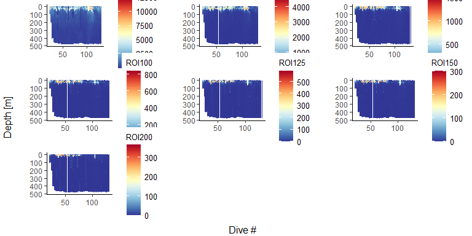

```r
#get ROIs
#which mission to select?
selroi = grep('*PtSur*',list.files(roipath_from_csvpath(datadir)))
rois = get_roi_counts(roipath_from_csvpath(datadir), selroi)

#plot ROI data
plot_roi(rois,roisel=NULL, skipdive=NULL,dres=1)
```

We could also just plot a selected ROI size:

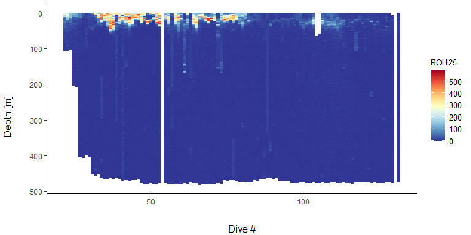

```r
plot_roi(rois, roisel='ROI125')
```

We can also join the acouistic data with the ROIs:

```r
#join Sv and ROI data
acroi <- join_ac_roi(Sv, rois)
```

We can have a look at the density distributions of ROI size vs Sv:

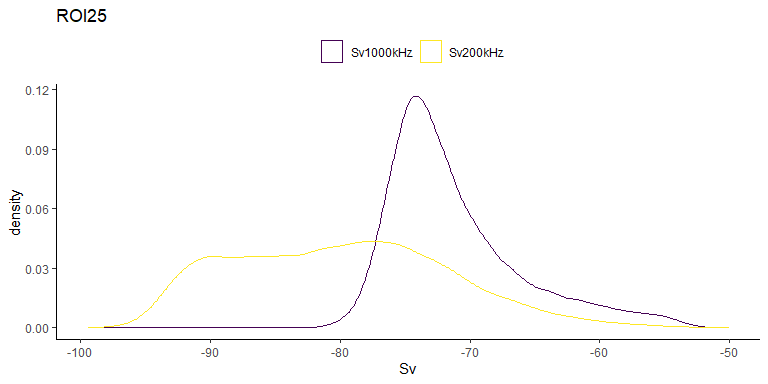

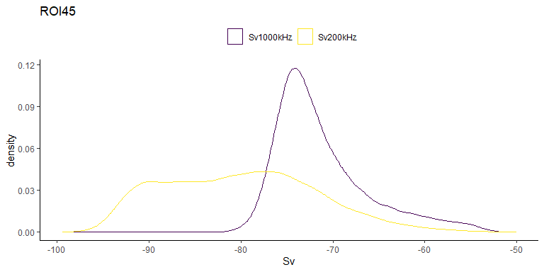

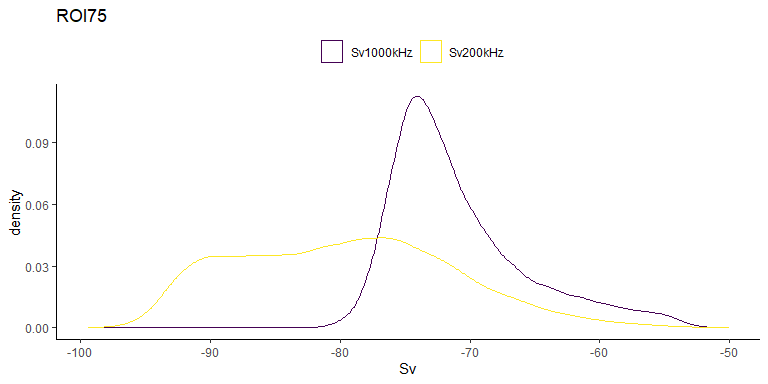

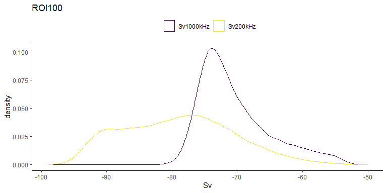

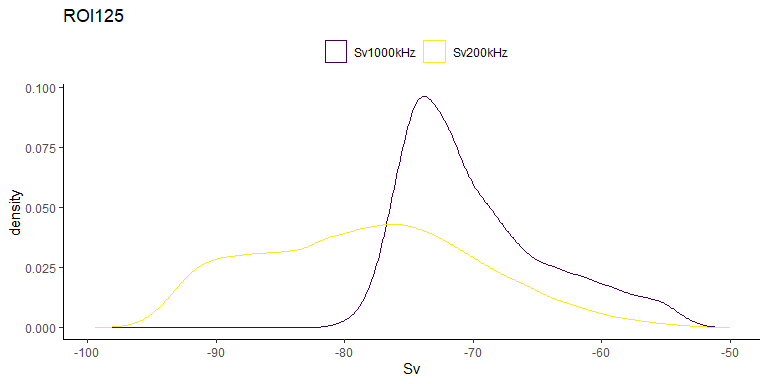

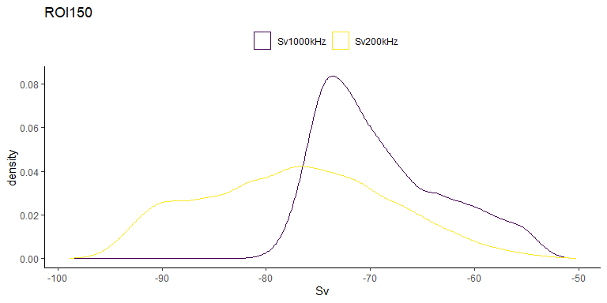

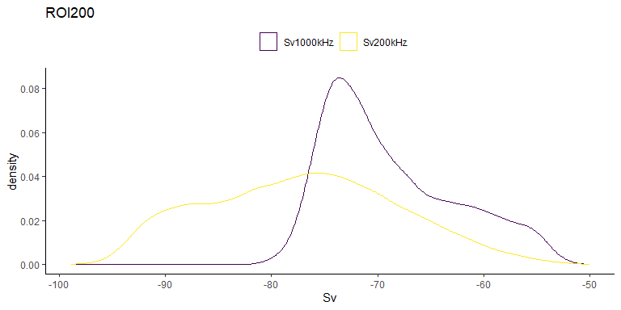

```r
roivars = names(acroi)[grep('ROI',names(acroi))]

for(v in roivars){
  sub = acroi[acroi[,v]>0,c('Sv200kHz','Sv1000kHz',v)]%>%gather(Freq,Sv,-eval(v))
  p<-ggplot(data=sub)+
    geom_density(aes(Sv, group=Freq, col=Freq))+
    scale_colour_viridis_d(name='')+
    ggtitle(v)+
    theme_classic()+
    theme(legend.position = 'top')
  print(p)
}
```

Or we can look at SvDelta vs ROIs:

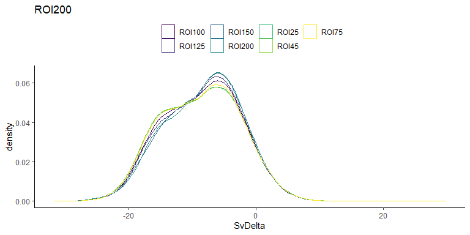

```r
roivars = names(acroi)[grep('ROI',names(acroi))]

sub = acroi[,c('SvDelta',roivars)]%>%gather(ROI,Count,-SvDelta)
sub = sub[sub$Count>0,]
  p<-ggplot(data=sub)+
    geom_density(aes(SvDelta, group=ROI, col=ROI))+
    scale_colour_viridis_d(name='')+
    ggtitle(v)+
    theme_classic()+
    theme(legend.position = 'top')
  print(p)
```

Now we can have a look at joined gams or regression trees for example to better understand the relationship between the ROIs and the acoustic data.

```r
#make gams and plots

#set depth cut value
dcut=200
#select daytime to analyze:
daytime = 'Day'

#loop through the different ROIs
for(v in c('ROI25','ROI45','ROI75','ROI125','ROI200')){
    cat("  ###",  v," for ", daytime,"  ")

  g1 =mgcv::gam(data=acroi[acroi$Depth<dcut & acroi$sun==daytime,],eval(parse(text=v))~s(Sv200kHz)+s(Sv1000kHz)+s(Sv200kHz, Sv1000kHz))
  summary(g1)

  b <- getViz(g1)
  print(plot(b, allTerms = T) +  l_fitRaster() + l_fitContour() + l_points(alpha=0.2)+ l_fitLine(linetype = 1, size=1.2) + l_fitContour() +
          l_ciLine(colour = 2) +
          scale_fill_gradientn(colors=rev(pals::brewer.rdylbu(12)) , na.value='transparent',oob=scales::squish)+theme_classic(), pages = 1)
}
```

### ROI25 for Day

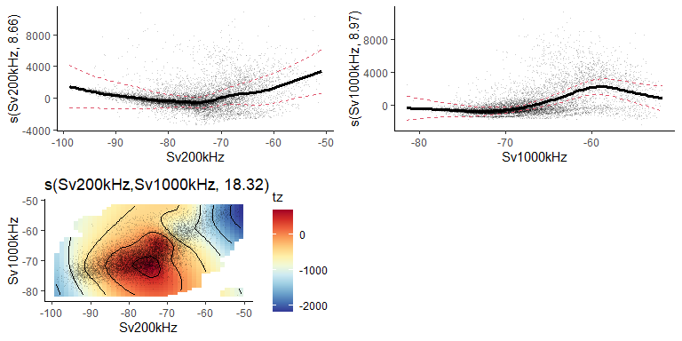

### ROI45 for Day

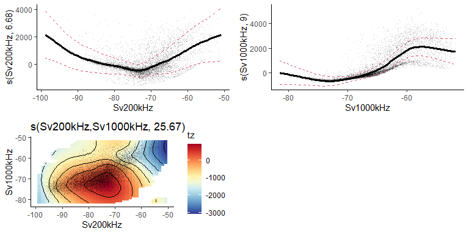

### ROI75 for Day

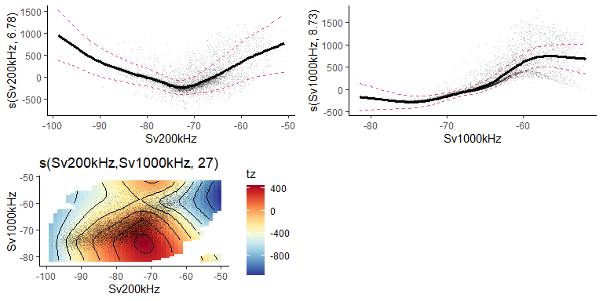

### ROI125 for Day

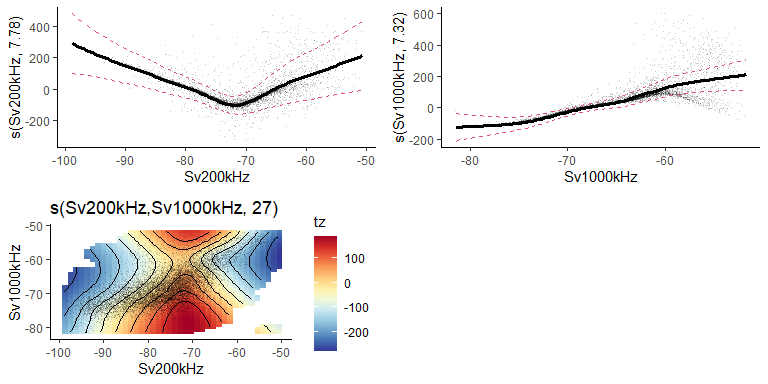

### ROI200 for Day

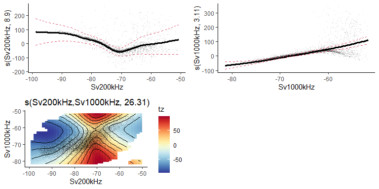

Or we look at it from another perspective:

```r
#make gams and plots

#set depth cut value
dcut=200
#select daytime to analyze:
daytime = 'Day'
rvars =c('ROI25','ROI45','ROI75','ROI125','ROI200')
#loop through the different ROIs
for(v in c('Sv200kHz','Sv1000kHz','SvDelta')){
    cat("  ###",  v," for ", daytime,"  ")

  g1 =mgcv::gam(data=acroi[acroi$Depth<dcut & acroi$sun==daytime,],eval(parse(text=v))~s(ROI25)+s(ROI200)+s(ROI25, ROI200)+s(ROI25, ROI125)+s(ROI25, ROI75)+s(ROI75, ROI200))
  summary(g1)

  b <- getViz(g1)
  print(plot(b, allTerms = T) +  l_fitRaster() + l_fitContour() + l_points(alpha=0.2)+ l_fitLine(linetype = 1, size=1.2) + l_fitContour() +
          l_ciLine(colour = 2) +
          scale_fill_gradientn(colors=rev(pals::brewer.rdylbu(12)) , na.value='transparent',oob=scales::squish)+theme_classic(), pages = 1)
}
```

### Sv200kHz for Day

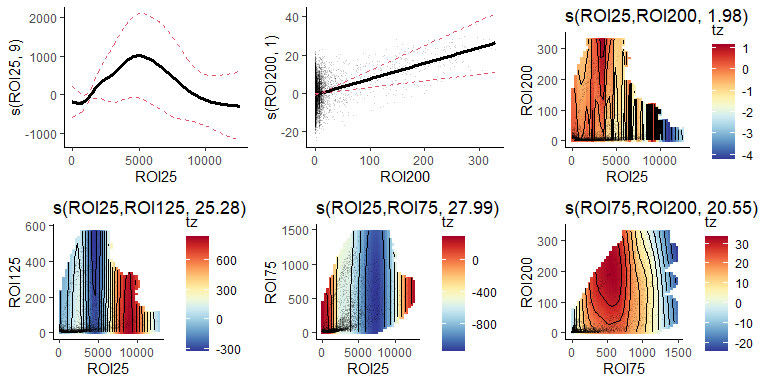

### Sv1000kHz for Day

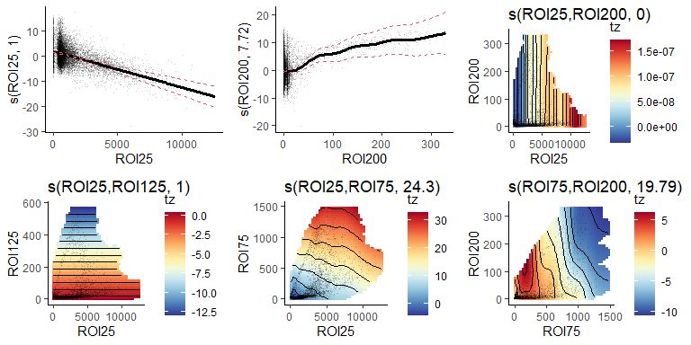

### SvDelta for Day

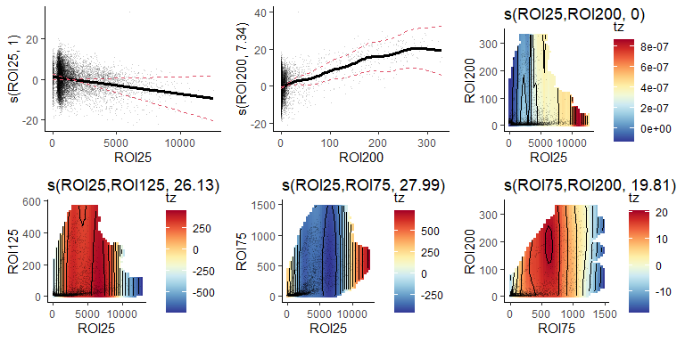

Similiarly we can look at regression trees to get a best classifier. Here an example for ROI 25:

```r
m1 <- rpart(
  formula = (ROI25) ~ Sv1000kHz + Sv200kHz + SvDelta,
  data    = acroi)
m1$variable.importance
```

```
##   Sv1000kHz    Sv200kHz     SvDelta
## 26506751563  8747840226    86983861
```

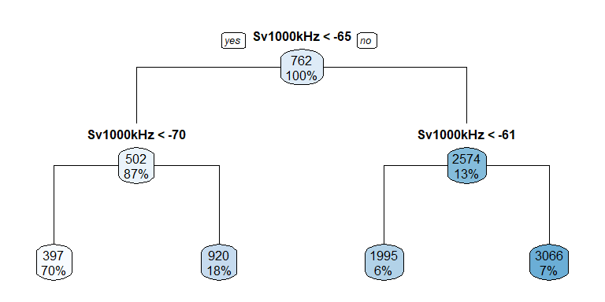

```r
rpart.plot(m1,type=1)
```

Or for ROI 200:

```r
m1 <- rpart(
  formula = (ROI200) ~ Sv1000kHz + Sv200kHz + SvDelta,
  data    = acroi)
m1$variable.importance
```

```
## Sv1000kHz  Sv200kHz   SvDelta
## 8256706.0 1679255.0  214996.4
```

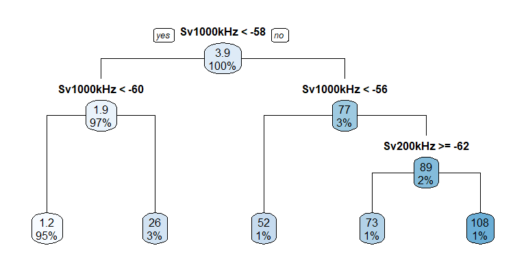

```r
rpart.plot(m1,type=1)
```